# GOV 1006 Problem Set 6

Maria Burzillo

4/7/2020

# Question 1

## a)

Before we run any models, we first filter the data to include only observations such that the presidential vote in 2012 was either for Romney or Obama and the presidential vote in 2016 was either for Clinton or Trump.

## b)

```
## stan_glm
##  family:       binomial [logit]
##  formula:      indicator_pres_vote_2016 ~ pres_vote_2012
##  observations: 6499
##  predictors:   2
## ------
##                           Median MAD_SD
## (Intercept)               -2.52   0.06
## pres_vote_2012Mitt Romney  5.56   0.11
##
## ------
## * For help interpreting the printed output see ?print.stanreg
## * For info on the priors used see ?prior_summary.stanreg
```

The simple print out of the model can be interpreted as follows. The intercept term corresponds to the logit probability of a voter who voted for Obama in 2012 voting for Trump in 2016, which is -2.52 with a mad_sd value of 0.06 . This can be interpreted much more easily by converting to the probability scale, which yields a coefficient of 0.07, which means that the probability of a voter who voted for Obama in 2012 voting for Trump in 2016 is 0.07.

```
##
## Model Info:
##  function:     stan_glm
##  family:       binomial [logit]
##  formula:      indicator_pres_vote_2016 ~ pres_vote_2012
##  algorithm:    sampling
##  sample:       4000 (posterior sample size)
##  priors:       see help('prior_summary')
##  observations: 6499
##  predictors:   2
##
## Estimates:
##                             mean   sd    10%   50%   90%
## (Intercept)               -2.52   0.07 -2.61 -2.52 -2.44
## pres_vote_2012Mitt Romney  5.56   0.11  5.41  5.56  5.70
##
## Fit Diagnostics:
##            mean   sd   10%   50%   90%
## mean_PPD 0.49   0.00 0.48  0.49  0.49
##
## The mean_ppd is the sample average posterior predictive distribution of the outcome variable (for details see help('summary.stanreg')).
##
## MCMC diagnostics
##                           mcse Rhat n_eff
## (Intercept)               0.00 1.00 2664
## pres_vote_2012Mitt Romney 0.00 1.00 2076
## mean_PPD                  0.00 1.00 2860
## log-posterior             0.03 1.00 1650
##
## For each parameter, mcse is Monte Carlo standard error, n_eff is a crude measure of effective sample size, and Rhat is the potential scale reduction factor on split chains (at convergence Rhat=1).
```

Further looking at the model summary gives us some additional information. For example, we can see 10th and 90th percentiles of the coefficient estimates. We can also see from the sd value that the confidence intervals on the estimates do not contain zero. Since the mad_sd values on both the intercept and the coefficient are also very low, this indicates a relatively high degree of certainty in these estimates.

## c)

Given that a voter voted for Obama in 2012, the probability that they voted for Donald Trump in 2016 is 0.07, as explained above.

Because we know the expected difference in the logit probability of voting for Trump between someone who voted for Obama and someone who voted for Romney from the coefficient in our model, we can also calculate the probability of a voter voting for Trump given that they voted for Romney. Our model suggests that voting for Romney instead of Obama corresponds to a positive difference of 5.56 in the logit probability of voting for Trump. Since we know that the logit probability of voting for Trump conditional of voting for Obama is -2.52, we can add these coefficients together to calculate the expected logit probability of a voter who voted for Romeny voting for Trump to be 3.03, or 0.95 converting to the probability scale.

# Question 2

## a)

```
##
## Model Info:
##  function:     stan_glm
##  family:       binomial [logit]
##  formula:      indicator_pres_vote_2016 ~ age
##  algorithm:    sampling
##  sample:       4000 (posterior sample size)
##  priors:       see help('prior_summary')
##  observations: 6499
##  predictors:   2
##
## Estimates:
##               mean   sd     10%    50%    90%
## (Intercept) -1.186  0.115 -1.335 -1.185 -1.042
## age          0.020  0.002  0.017  0.020  0.022
##
## Fit Diagnostics:
##            mean   sd    10%   50%   90%
## mean_PPD 0.490  0.009 0.478 0.490 0.501
##
## The mean_ppd is the sample average posterior predictive distribution of the outcome variable (for details see help('summary.stanreg')).
##
## MCMC diagnostics
##               mcse  Rhat  n_eff
## (Intercept)   0.002 1.001 2965
## age           0.000 1.001 2915
## mean_PPD      0.000 1.002 3108
## log-posterior 0.024 1.002 1788
##
## For each parameter, mcse is Monte Carlo standard error, n_eff is a crude measure of effective sample size, and Rhat is the potential scale reduction factor on split chains (at convergence Rhat=1).
```

We can interpret the coefficient here using the divide by 4 rule. Dividing the coefficient on age by 4 yields 0.0049. This suggests that a difference of one year in age leads to a maximum increase of 0.0049 in the probability of voting for Trump. However, taking the inverse logistic function of the coefficient to convert to probability yields 0.5, which, very differently, suggests that a difference of one year in age leads to an increase in probability of voting for Trump by 0.5 per year. This does not make sense, as this would imply that a 2 or more year difference would lead to an expected increase of more than 1 on a probability scale. It may be that because the coefficient is so low in terms of logit probability, that the transformation here is somehow warping the result. Ideally, we should dig into this more as the divide by 4 rule should approximate the conversion to probability scale using plogis() near the midpoint of the logistic curve where the probabilities are close to .5.

## b)

Based on our posterior prediction, the median likelihood of a 25 year old individual voting for Trump is expected to be 0.33 and the median likelihood of a 75 year old individual voting for Trump is expected to be 0.57. Thus, the predicted difference in the likelihood of voting for Trump is 0.24 between 75 year olds and 25 year olds.

# Question 3

## a)

Currently, the income variable is in U.S. dollars. This may be an issue when interpreting the coefficient of the model because it would give us information about the change in probability of voting for Trump corresponding to a change in one dollar of income, which is not very meaningful. Thus, it is more helpful to examine income in terms of tens of thousands of dollars.

## b)

```
##
## Model Info:
##  function:     stan_glm
##  family:       binomial [logit]
##  formula:      indicator_pres_vote_2016 ~ age + income_10k
##  algorithm:    sampling
##  sample:       4000 (posterior sample size)
##  priors:       see help('prior_summary')
##  observations: 5708
##  predictors:   3
##
## Estimates:
##               mean    sd      10%     50%     90%
## (Intercept) -1.2957  0.1373 -1.4774 -1.2924 -1.1218
## age          0.0202  0.0021  0.0175  0.0202  0.0229
## income_10k   0.0091  0.0067  0.0003  0.0092  0.0176
##
## Fit Diagnostics:
##            mean   sd     10%    50%    90%
## mean_PPD 0.4847 0.0093 0.4730 0.4844 0.4967
##
## The mean_ppd is the sample average posterior predictive distribution of the outcome variable (for details see help('summary.stanreg')).
##
## MCMC diagnostics
##               mcse   Rhat   n_eff
## (Intercept)   0.0022 1.0005 3894
## age           0.0000 1.0002 3926
## income_10k    0.0001 1.0000 4109
## mean_PPD      0.0002 1.0013 3562
## log-posterior 0.0280 1.0007 1793
##
## For each parameter, mcse is Monte Carlo standard error, n_eff is a crude measure of effective sample size, and Rhat is the potential scale reduction factor on split chains (at convergence Rhat=1).
```

The coefficient on age in the model is 0.0202. This suggests that a one year difference in age corresponds to an increase of 0.0202 in logit probability of voting for Trump. We can use the divide by four rule to estimate this same relationship on the probability scale. Dividing by four yields the value 0.005, which suggests that a one year difference in age corresponds to an increase in the probability of voting for Trump of 0.005.

The coefficient of income in the model is 0.0092. This suggests that $10,000 difference in income corresponds to an increase in the logit probability of voting for Trump of 0.0092. Using the divide by four rule, we get the value of 0.0023, which suggests that a $10,000 increase in income corresponds to a 0.0023 increase in the probability of voting for Trump.

## c)

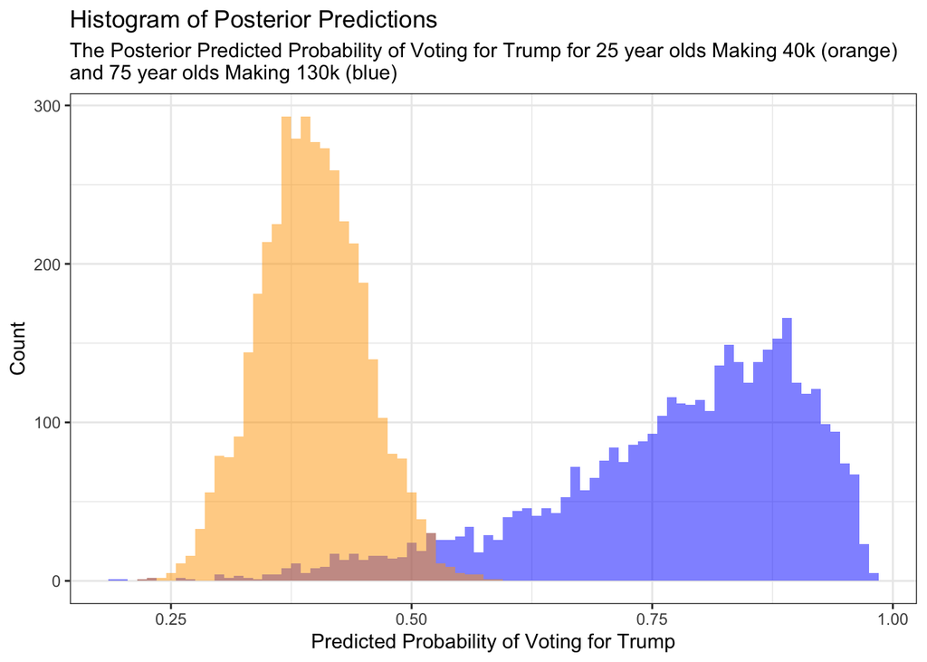